# Laboratorio 2.1: Clasificación

## Pregunta 2.5

El siguiente código genera una matriz de confusión de los resultados de clasificación de la pregunta 2.4. Ejecute el bloque completo para visualizar el gráfico. Interprete la matriz y comente sobre cada uno de los valores distintos de 0 en la matriz y describa lo que representa.

*Verifique que los resultados que se imprimen concuerden con su respuesta (por el factor aleatorio del estimador). Nota: Para obtener un comportamiento determinista existe el parámetro **random_state**, por ejemplo: clf = DecisionTreeClassifier(random_state=2).*

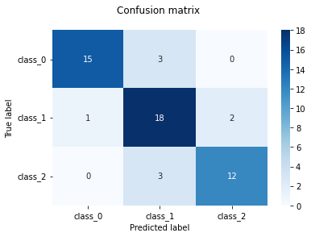

```python
## EJECUTAR ESTE BLOQUE

from sklearn.metrics import confusion_matrix
from sklearn.utils.multiclass import unique_labels

# Compute confusion matrix. By default is not normalized (normalize=None)
# If necessary change 'y_pred' according to your variable name
cm = confusion_matrix(y_test, y_pred)

# Only use the labels that appear in the data
classes = wine.target_names[unique_labels(y_test, y_pred)]

df = pd.DataFrame(cm, index = classes, columns = classes)

g = sns.heatmap(df, annot=True, cmap="Blues")
g.set_yticklabels(g.get_yticklabels(), rotation = 0)

plt.title('Confusion matrix \n')
plt.xlabel('Predicted label')
plt.ylabel('True label')

plt.autoscale()
```

### Respuesta a pregunta 2.5

Con respecto a la primera columna, el 15 indica que hay 15 datos que pertenecen a las clase 0 y fueron predichos correctamente. El 1 de la primera columna indica que hubo un dato que es de clase 1 pero fue predicho erroneamente como clase 0.  
Con respecto a la segunda columna, el 3 indica que hubieron 3 datos que son clase 0 pero fueron predichos clase 1, de igual manera, el 3 indica que hubo 3 datos clase 2 predichos como clase 1 y el 18 fueron los datos correctamente predichos.  
Análogamente, en la tercera columna, el 2 indica que hubo 2 datos clase 1 que fueron predichos como clase 2 y que hubieron 12 correctamente clasificados.

## CLASIFICADOR 3

Para este clasificador utilizaremos Cross-validation. Con cross-validation, el conjunto de entrenamiento se divide en $k$ conjuntos disjuntos; se entrena sobre los datos correspondientes a $k-1$ de éstos, y se evalúa sobre el conjunto restante. Esto se repite $k$ veces, evaluando siempre sobre un conjunto distinto. Teniendo en cuenta el parámetro $k$, a éste método se le llama $k$-fold cross-validation.

El código que está a continuación realizará 10-fold cross-validation usando Decision Tree sobre los datos. La forma de estimar el rendimiento del clasificador es, entre otras cosas, calculando el promedio de todos los k-folds.

```python
## EJECUTAR ESTE BLOQUE

from sklearn.model_selection import cross_validate
import numpy as np

scoring = ['precision_macro', 'recall_macro', 'accuracy', 'f1_macro']
cv_results = cross_validate(clf, X, y, cv = 10, scoring = scoring, return_train_score= True)

print('Promedio Precision:', np.mean(cv_results['test_precision_macro']))
print('Promedio Recall:', np.mean(cv_results['test_recall_macro']))
print('Promedio F1-score:', np.mean(cv_results['test_f1_macro']))
print('Promedio Accucary:', np.mean(cv_results['test_accuracy']))

#Si quisieramos mostrar el resultado de cada k-fold, deberiamos quitar la
#funcion np.mean la cual retorna el promedio. Esto mostraría una lista con el resultado de cada fold
```

```
Promedio Precision: 0.8532142857142857
Promedio Recall: 0.8630158730158731
Promedio F1-score: 0.8478839189133307
Promedio Accucary: 0.8594771241830067
```

## Pregunta 3.1

- Compare los valores de las métricas con respecto a lo obtenido en la pregunta 2.4 y comente en qué difieren y por qué.
- ¿Qué beneficios tiene emplear cross-validation?

### Respuesta a pregunta 3.1

Si bien los resultados cambian, su diferencia no es significativa para este ejemplo.  
El valor de precision fue muy parecido para ambas maneras de obtener las métricas al igual que el f1-score.  
Con respecto al accuracy, se ve un ligero incremento de 0.03 aproximadamente a favor de cross-validation.  
Así mismo, el recall también tiene un incremento de $\sim$ 0.03 en el método de cross-validation.  
Usar cross-validation entrega el beneficio de ser más estable al realizar el proceso k veces en contraposición del ejercicio 2.4 que lo realiza sólo 1 vez.